# Final Paper

STOR 320.02 Group 7

December 07, 2023

# INTRODUCTION

Yu-Gi-Oh is the namesake of the manga, show, and card game created by Kazuki Takahashi and beloved by millions. The game was first created in the late nineties, and cards are still being released today. Yu-Gi-Oh cards are typically sold in packs, but they can also be resold and purchased individually through secondary markets. A single Yu-Gi-Oh card can range in price from less than $1 to over $500. Our group was interested in the community of people that scour the market in search of the cheapest Yu-Gi-Oh card prices, and we wanted to identify ways to help them obtain cards cost-effectively.

There are three primary Yu-Gi-Oh card types: Monster, Spell, and Trap. Each card has several characteristics, such as *Rarity*. Trends in these characteristics have been meticulously crafted by the creators of the game, which was interesting to investigate in the early stages of our data analysis. However, we realized that the resell prices of the cards were something that the game’s manufacturers couldn’t manipulate. Thus, we wanted to know if we could use card characteristics to predict their mean prices, combining information provided by the manufacturer, Konami, with data entirely out of their control. This information could be especially valuable to Yu-Gi-Oh players that collect and sell cards.

Beyond considering the best predictors of Yu-Gi-Oh card prices, we were especially interested in the format in which someone can buy a card—in a booster box, in a booster pack, or as an individual card. Our group was interested in how to collect a complete card set for the cheapest cost, so we decided to compare the costs of buying booster boxes to buying cards individually. A comparison of these two purchasing methods could change the way a Yu-Gi-Oh collector would approach obtaining full sets.

Though Yu-Gi-Oh has a relatively niche audience, the game has a very active and accessible market. Anyone can buy a card set, and anyone can buy cards individually. Ultimately, our goal is to identify the most important variables in predicting Yu-Gi-Oh card prices, as well as determine the most cost-effective way to purchase entire card sets.

# DATA

Our original dataset was found on Kaggle, created by data scientist Archan Ghosh who collected the data of Yu-Gi-Oh cards from the official Yu-Gi-Oh website<sup>1</sup>. The dataset is a sample of all of the cards within the Yu-Gi-Oh TCG (Trading Card Game), of which there are over 12,000 cards as cataloged by the Yu-Gi-Oh! Fandom Wiki<sup>2</sup>. Each observation in our dataset represents a singular Yu-Gi-Oh card and its characteristics. There are 8,361 unique cards in the original dataset, as determined by the *Card_number* variable, which specifies a card’s unique identification. The initial dataset contains 23 variables, but we primarily focused on 10. The variables that we paid less attention to were simply identifiers or contained majority NA values. The visual below details these 10 variables but also includes *Card Names* and *Card Numbers*.

```
## Rows: 8,373
## Columns: 12
## $ Card.Name    <chr> "Witch of the Black Forest", "Plasma Ball", "Koa'ki Meiru…
## $ Card.Number  <chr> "MRD-116", "PHSW-EN014", "ROTD-EN030", "PGD-093", "RIRA-E…
## $ Card.Type    <chr> "Monster", "Monster", "Monster", "Trap", "Spell", "Monste…
## $ Card.Set     <chr> "Metal Raiders", "Photon Shockwave", "Rise of the Duelist…
## $ Rarity       <chr> "Rare", "Common", "Ultra Rare", "Rare", "Common", "Common…
## $ Property     <chr> "", "", "", "Continuous", "Field", "", "Continuous", "", …
## $ Types        <chr> "Spellcaster / Effect", "Thunder / Effect", "Rock / Effec…
## $ Effect.Types <chr> "['Trigger', 'Condition']", "['Continuous', 'Trigger']", …
## $ Attribute    <chr> "DARK", "LIGHT", "EARTH", "", "", "WIND", "", "EARTH", "E…
## $ Level        <int> 4, 3, 4, NA, NA, 9, NA, 4, NA, 4, 1, NA, 1, 4, NA, NA, 11…
## $ Attack       <int> 1100, 900, 1400, NA, NA, 0, NA, 1200, 2400, 1800, 1000, N…
## $ Defense      <int> 1200, 900, 1600, NA, NA, 3000, NA, 1200, 2800, 1200, 1000…
```

In our pursuit to predict prices based on different variables, we modeled our data using 10 different variables: *Card Type*, *Card Set*, *Rarity*, *Property*, *Types*, *Effect Types*, *Attribute*, *Level*, *Attack*, and *Defense.* *Card Type* can be one of three categories: Monsters, Spells, or Traps, with over 60% being monsters. *Card Sets* refer to the set, or group, that the card was released in (Ex: Legend of Blue Eyes White Dragon or Battle of Chaos). Intuitively, *Rarity* denotes the value of the card with different printings (Ex: Common, Rare, Super Rare, etc.). The *Property* variable denotes which phase of the game a Spell or Trap card can be used in (Ex: Normal, Continuous, Quick-Play, etc.). Additionally, the *Type* variable refers to what family of monsters a card belongs to (Ex: Dragons, Zombies, Machines, etc.). *Attribute* determines the elemental group that Monster cards belong to (Ex: Light, Wind, Earth, Dark, Fire, or Water). The *Level* is a value that describes a card’s power and can range from 1 to 12. *Attack* and *Defense* describe the power points of cards in dealing or receiving damage. Note that *Attack* and *Defense* were stored in our original dataset as one variable, *ATK…DEF*. We split this original variable using the separate function so we could individually analyze each point for its impact on price. We also created two additional variables during the modeling process: *Number of Types* and *Number of Effect Types*. These variables count each card’s individual *Types* and *Effect Types* to further describe the data and were also used in the modeling process.

The initial data did not include the prices of the cards. Thus, we began the tedious process of scraping this information from the internet. The price data was scraped from YugiohPrices<sup>3</sup> using the SelectorGadget CSS selector tool<sup>4</sup>. YugiohPrices checks nine different online merchants, including eBay, TCGPlayer, and Amazon, calculates several price metrics, and updates its information every one to four hours. We last scraped data on November 1st, 2023, collecting *Low*, *High*, and *Mean Price* data. After accounting for the values we were unable to web-scrape, we were left with 4,953 observations representing 3,196 Monster, 956 Spells, and 801 Traps. The following proportion table shows the distribution of these 4,953 cards across *Rarity* and *Card Type*.

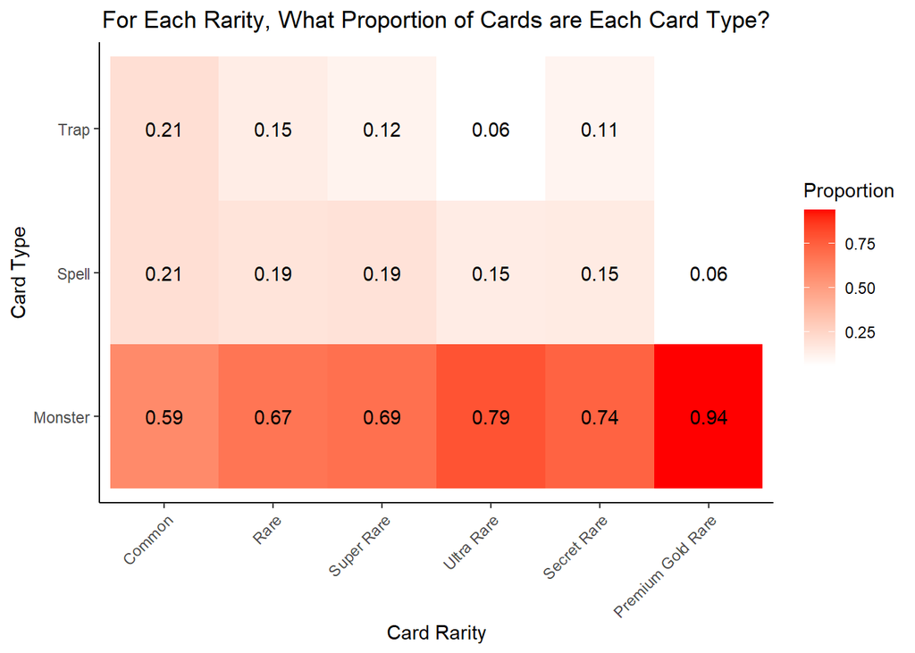

We encountered a few hurdles throughout our web scraping process. The first issue we noticed was that the website contained data for several cards with identical names but different *Card Numbers*. For example, the page for a card named “Witch of the Black Forest” contained information on 10 different cards, each with a unique card number. We used a method of extracting the data, concatenating the prices/card numbers into strings with separators, splitting the strings, and matching them to their corresponding *Card Names*. With this approach, for the aforementioned card, we would theoretically scrape a string containing 10 mean prices and 10 card numbers. We could separate each card number into a unique observation with associated price data and then use a joining function to keep only the data for the specific card codes contained in our dataset. Scraping the price data was difficult since the data was contained within separate tables of the card’s lowest, highest, and average price. In using rvest’s html_table function on the entire webpage, many unnecessary tables were scraped, so we needed to find a way to only scrape those containing price data. Eventually, we discovered that our desired data was present in the fifth table and every subsequent fourth table (i.e. 5, 9, 13, etc.). So we scraped only these tables. After the prices and card numbers were scraped, we used the separate_rows function to split the strings into individual observations and then used the left_join function to merge this data with our initial dataset. Additionally, regarding our second question and our goal to determine which format to purchase cards (in booster boxes or individually), we manually scraped market price data for three complete Card Sets: Legend of Blue Eyes White Dragon, Maximum Gold, and Battle of Chaos. We collected this data from TCGPlayer<sup>5</sup>. Unlike the initial price data, this data was contained in dynamic tables and we were unable to automate R to scrape them after several attempts. Thus, we manually copied this information into an Excel file for our later use.

# RESULTS

## Modeling

Importantly, several variables are only applicable to either Monster or Spell and Trap cards. Specifically, the variables *Attribute*, *Types*, *Number of Types*, *Level*, *Attack*, and *Defense* are exclusive to Monster cards, while *Property* is exclusive to Spell and Trap cards. However, *Card Set*, *Rarity*, *Effect Types*, and *Number of Effect Types* apply to all card types. With these specificities in mind, to address our first question, we divided our dataset into three groups for each of the primary card types. Overall, we set out to create four models: one for each *Type* and one for all cards.

For Spells and Traps, the important variables for predicting *Mean Price* are *Card Set*, *Rarity*, *Number of Effect Types*, and *Property.* All possible combinations of these variables, the empty model, and polynomial models of degrees 2 and 3 for the *Number of Effect Types* were used. A total of 18 models were evaluated for out-of-sample mean absolute error (MAE) using leave-one-out cross-validation methods. For Spells, the best-performing model was *Rarity*, with an MAE of about 2.17, although *Rarity* + *Number of Effect Types* was a close second with an MAE of about 2.18. Comparatively, the Empty model had an MAE of about 2.34, and the worst-performing model, *Card Set* + *Number of Effect Types* + *Property*, had an MAE of about 2.68. As a group, we decided that the best model was *Rarity*, due to its low MAE and simplicity relative to *Rarity* + *Number of Effect Types*. For Traps, the best-performing model was *Rarity* + *Property* with an MAE of about 1.9106, although *Rarity* was a very close second with an MAE of about 1.9108. Comparatively, the Empty model had an MAE of about 1.96, and the worst-performing model, the Full model, had an MAE of about 2.34. For Traps, we concluded that the *Rarity* model was likely the best due to its small difference between the best-performing model MAE-wise and its overall simplicity. The predictions from the best model for Traps and Spells are plotted below. Note that our dataset did not contain Traps with a *Rarity* of Premium Gold Rare.

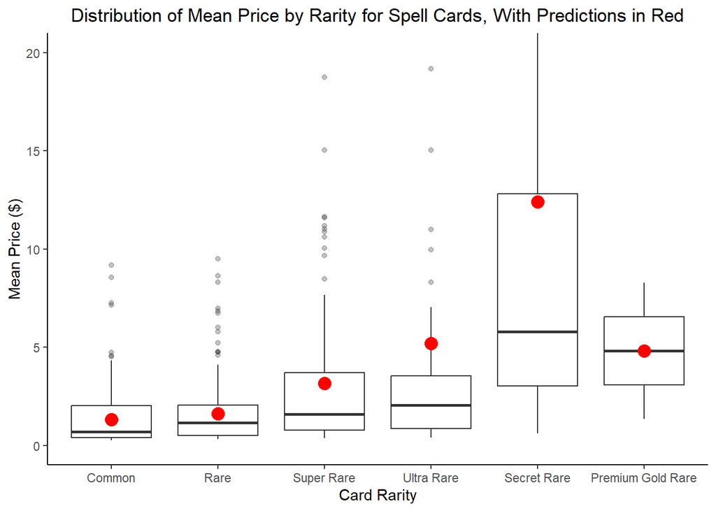

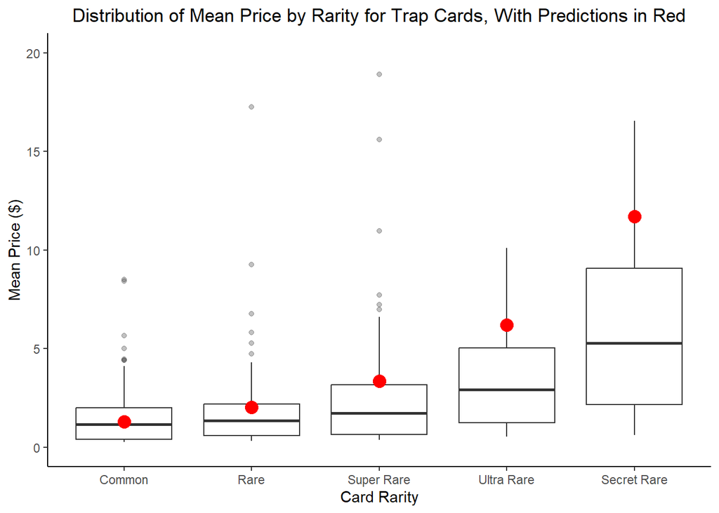

Overall we determined that *Rarity* was the best predictor for the prices of Spells and Traps. However, we were limited by the number of variables to model. Further, the number of observations was small and insufficient to support the reliable inclusion of interaction variables. As R put it, “prediction from a rank-deficient fit may be misleading.” In other words, when interaction terms were considered, there were not enough observations in each group to reliably include them in the analysis. This same issue was present with Monsters.

For Monsters, the important variables for predicting *Mean Price* are *Rarity*, *Attack*, *Defense*, *Card Set*, *Level*, the sum of *Attack* and *Defense*, *Effect Types*, *Number of Effect Types*, and *Attribute.* A total of 11 models were evaluated for out-of-sample MAE using leave-one-out cross-validation. Again, the *Rarity* model had the lowest MAE of 3.77, followed by *Rarity* + *Number of Effect Types* with an MAE of 3.83. The worst-performing model was the Full model, with an MAE of 6.11. Overall, we concluded that *Rarity* was also the best predictor of *Mean Price* for Monsters. The predictions of that model are again plotted over the original data below. For this visual and for the model of all cards we did not plot the Ghost Rare or Starlight Rare *Rarities*, as they only contained 2 and 3 cards respectively and had very high predictions. These *Rarities* were still included in our model and MAE calculations. We also noticed that the MAE of Monster cards was typically higher than the MAEs for Spell and Trap cards. We concluded that this is because Monster *Mean Prices* have a significantly larger distribution, with some prices as high as $600 or more. The boxplots below show a wider distribution for Monster cards. Thus, it is logical for Monster cards to have greater MAEs than Spell and Trap cards.

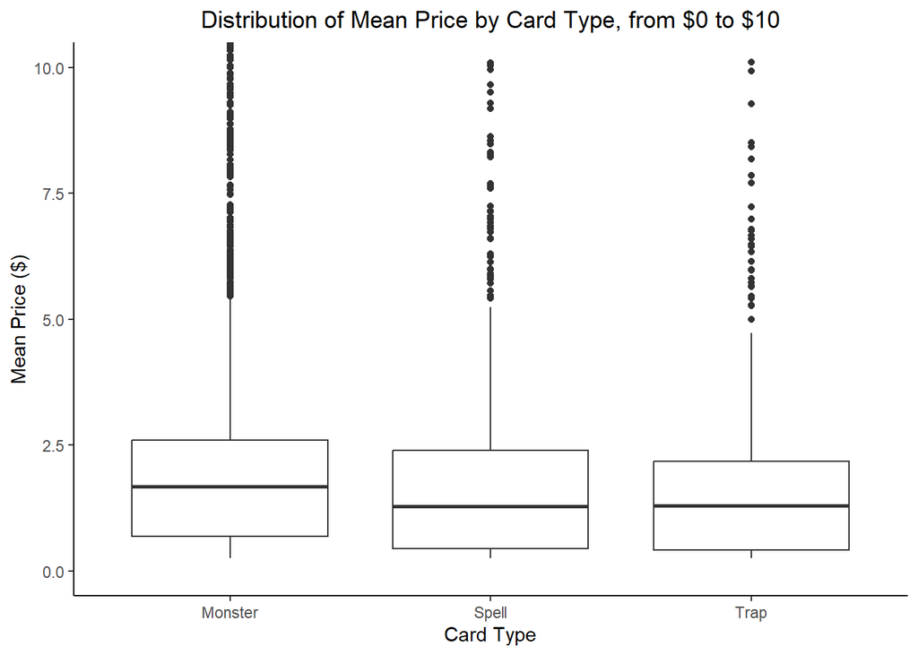

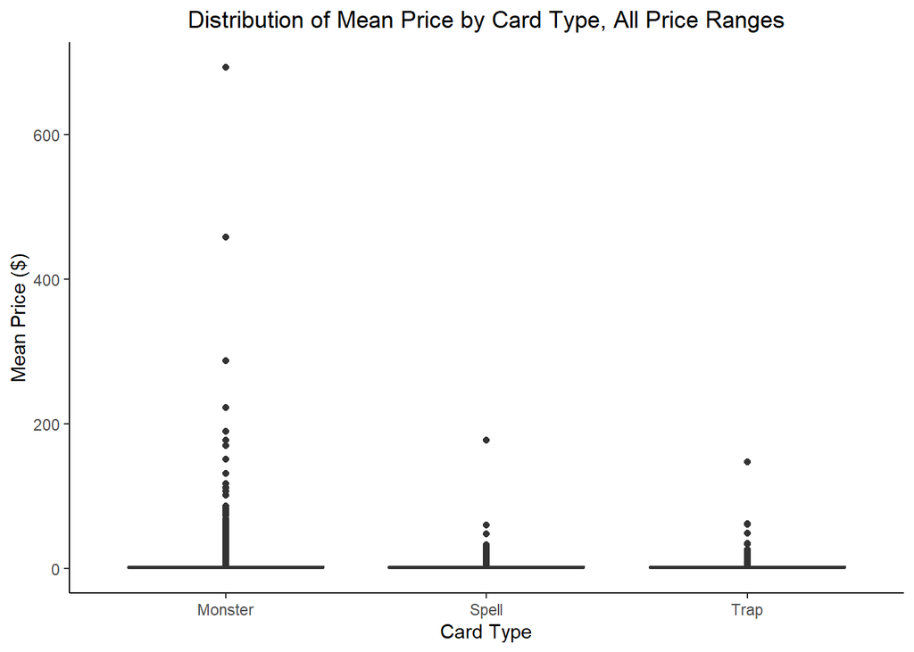

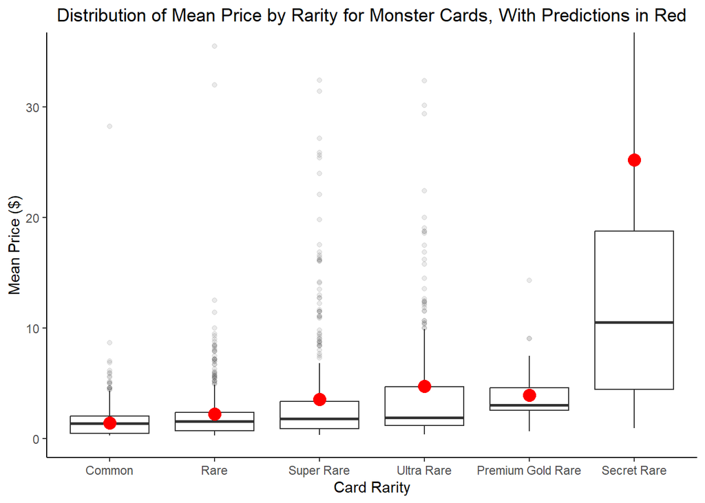

Finally, we used similar models to attempt to predict the *Mean Price* of all cards—a combination of Monsters, Traps, and Spells. We made models using the variables *Rarity*, *Card Set*, *Effect Types*, *Number of Effect Types*, and *Card Type*. We found that *Rarity* + *Number of Effect Types* was the best model, with an MAE of 3.196. *Rarity* was a very close second, with an MAE of 3.200. Similar to our conclusion for Trap cards, the simplicity and near-best performance of the *Rarity* model favor its selection as the best model overall. The best model for all cards is plotted below, as well as a table of calculated MAE values of selected models for each card type. In conclusion, we learned that the best predictor for *Mean Price* was *Rarity* with each of our card categories. While this conclusion was unsurprising, we were surprised by its similar performance to other models. We expected *Rarity* to be the best predictor by far, and our results show that it just barely outperformed other variables.

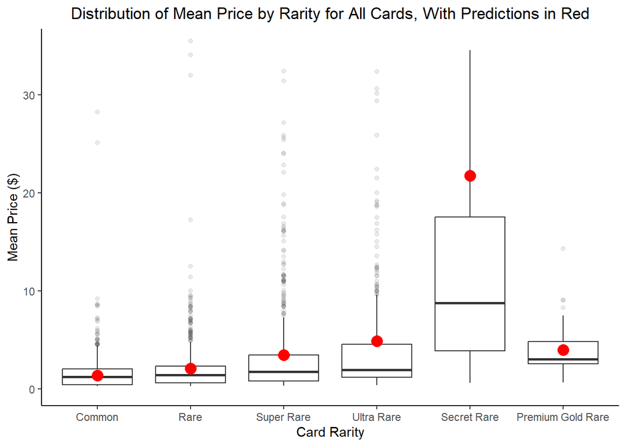

Calculated Out-of-Sample MAE for Selected Models

| Model Name | Our Created Models Spell | Our Created Models Trap | Our Created Models Monster | Our Created Models All |
| --- | --- | --- | --- | --- |
| Rarity | 2.173212 | 1.910847 | 3.774148 | 3.20017 |
| Rarity + Number of Effects | 2.178445 | 1.917011 | 3.829066 | 3.196866 |
| Rarity + Property | 2.207731 | 1.910604 | … | … |
| Rarity + Number of Effects + Property | 2.215409 | 1.916607 | … | … |
| **Boundary Models** |  |  |  |  |
| Empty | 2.343934 | 1.964392 | 5.318545 | 4.22095 |
| Full | 2.624221 | 2.344537 | 6.106591 | 3.835848 |

## Simulation

For the simulation, we compared the purchase of booster boxes to the purchase of individual cards. To clarify, a card set is a group of cards that are released by Konami at once, typically containing 100 different cards of assorted *Rarities.* The smallest unit of a group of cards is a card pack or booster pack, which usually contains 9 cards and costs around $4. A typical booster pack is guaranteed to have 8 cards with “Common” *Rarities* and 1 card with a more valuable *Rarity.* The order of *Rarity* from least valuable to most valuable is as follows: “Rare,” “Super Rare,” “Ultra Rare,” “Secret Rare,” and sometimes there are exclusive rarities such “Premium Gold Rare” and “Starlight Rare.” Each of these *Rarities* has a different probability of appearing per booster pack, with “Rare” having the highest probability. A booster box contains 24 card packs of a given card set. Essentially, we wanted to determine whether buying boxes or individual cards would be more cost-effective in collecting all unique cards in a set.

We chose three card sets to investigate through our simulations: Battle of Chaos, Maximum Gold, and Legend of Blue Eyes White Dragon. The Battle of Chaos card set came out in 2022 and acts as a representation of a typical, recently released card set. It costs $61.99 on the TCG website for an unopened box of Battle of Chaos cards. The second set, Maximum Gold, is a specialty card set that came out in 2020. Maximum Gold booster boxes, which are priced at $25.73, cost less in comparison to other boxes because they contain 4 card packs each instead of the standard 24 packs per box. Maximum Gold card packs also only contain 7 cards each instead of the typical 9. Card packs of this set contain entirely rare cards, with 5 being Rare and 2 being Premium Gold Rare. We chose this set to vary the types of card sets we examined, and to see if the results of our simulations would differ. Finally, we simulated the Legend of Blue Eyes White Dragon, which was the first card set ever released by Yu-Gi-Oh and has accrued in value to collectors over time. As a result, there is a large disparity between the market price of sealed boxes of this set and the market price of unsealed cards which have accumulated damage over the years. To consider the value that these cards would have in near-mint condition, we pulled price data from PSA, Professional Sports Authenticator, which grades cards based on their condition and determines their subsequent prices. For each of these card’s prices, we subtracted their cost of being graded to represent the fee of submitting a card to be graded by PSA and the fee varies based on the declared value of the card. Based on the typical grades of Legend of Blue Eyes White Dragon cards, we assumed that a all of the submitted cards in this set would receive near mint grades of 8.

To answer our question, we created a simulation to represent the purchase of booster boxes. Using the probabilities released by Konami for Yu-Gi-Oh for the different *Rarities*, we randomly sampled the probabilities of receiving specific cards in a card set. For example, the probability of receiving an Ultra Rare card in a card pack of the Legend of Blue Eyes card set is 1/12. There was some difficulty in determining the probabilities of Secret Rare cards and Starlight Rare because this information was not released by YuGiOh officially. After consulting forums and Yu-Gi-Oh community websites, we determined the most likely probabilities for these cards depending on the card set. While the true probability is most likely very similar to the probabilities we found, it is important to note that these are not officially released by Konami. For Battle of Chaos, each trial of our simulation took an average of 2 minutes to run, so about 33.33 hours for 1000 trials. Because Starlight Rare cards have such a small probability of being included in a card pack (1/576), we had to simulate opening many packs of cards to collect the final unique starlight rares. For example, we expected to open 2880 packs to find the final Starlight Rare after collecting the 4th unique Starlight Rare card using the formula {1/(((5-n)/5)*(1/576))} for n=4. To account for time, we added a while loop condition to stop the simulation after collecting any 5 Starlight Rares (including duplicates), rather than all 5 unique Starlight Rares. With this method, we measured the cost of purchasing the unique Starlight Rare cards that we hadn’t collected and factored this value into the final_spending of each trial.

To simulate the opening of a box within a card set, we first simulated the process of opening a singular pack. The function, open_pack, samples certain number of cards depending on the set using a list of probabilities for each *Rarity.* Then, the function simulation_box uses the function open_pack to open however many card packs would typically come in that card set’s booster box. We used a while loop to continue opening boxes until we reached the number of total unique cards that come in that specific card set. As the loop runs, it counts how many boxes we open and keeps track of the specific cards we accumulate. We ran each simulation 1000 times. After the simulations were completed, we subtracted the total cost from the potential revenue to find the final spending. If this value was negative, we paid money (compared the total price spent buying card boxes to the potential price of purchasing the cards individually). To visualize the distribution of our simulations, we created histograms of the final spending. This allowed us to see if the visualization approximated the normal distribution. To set the number of bins for each graph, we used the Freedman-Diaconis<sup>6</sup> rule, because it considers both the sample size and spread of the sample. The formula for the Freedman-Diaconis rule is displayed below as well. The red line on each graph marks the cost (thus displayed as negative) of purchasing all cards in a card set individually.

$$Bin\;Width = \frac{2(q3 -
q1)}{\sqrt[\leftroot{-1}\uproot{2}\scriptstyle 3]n}$$

$$Bins =
\frac{max(x)-min(x)}{Bin\;Width}$$

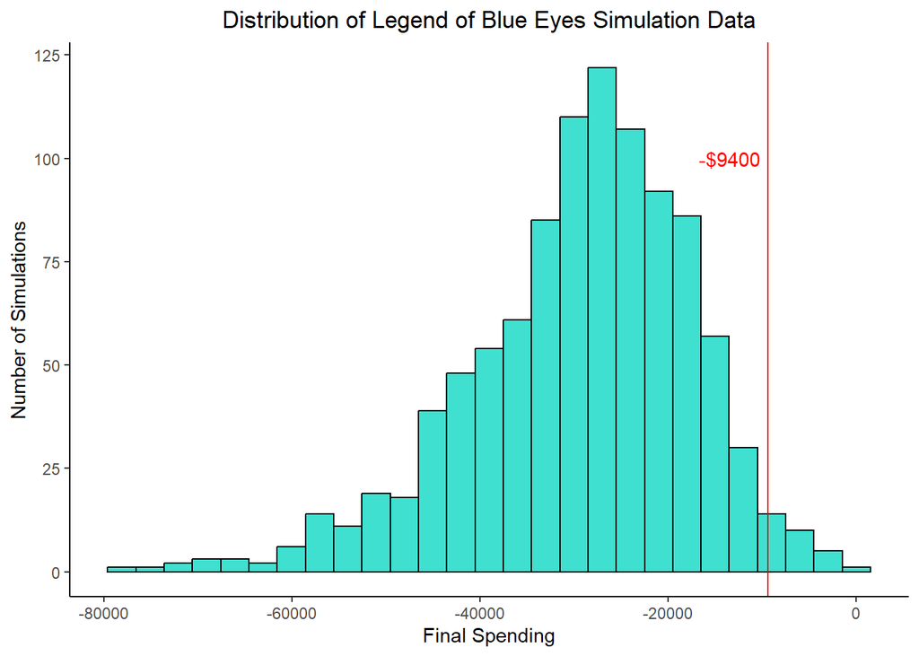

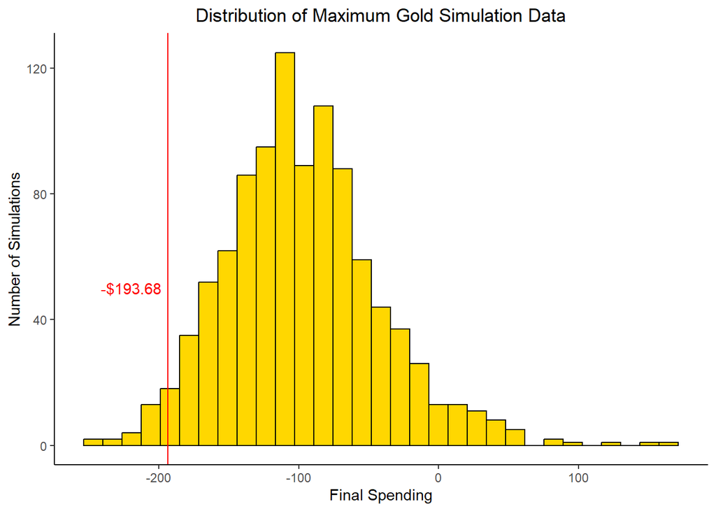

Since we bought multiple boxes in an attempt to collect all cards within a card set, we were left with a plethora of duplicate cards. Assuming that we could sell all of our duplicate cards at market price, we calculated the potential revenue we could make from our resells and subtracted that from what we spent buying all the booster boxes. This left us with our final_spending variable. If final_spending was positive, it meant that we had collected all of the unique cards of the set, sold our duplicates, used the revenue from the duplicates to pay off the expense of buying booster boxes, and still had money left over. If final_spending was negative, we paid that amount to obtain all unique cards in the set by opening booster boxes.

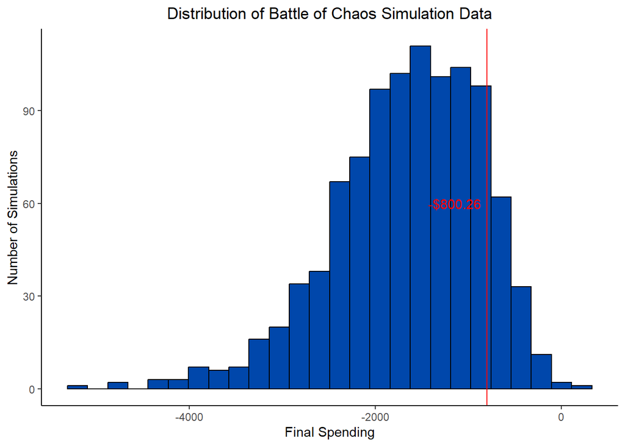

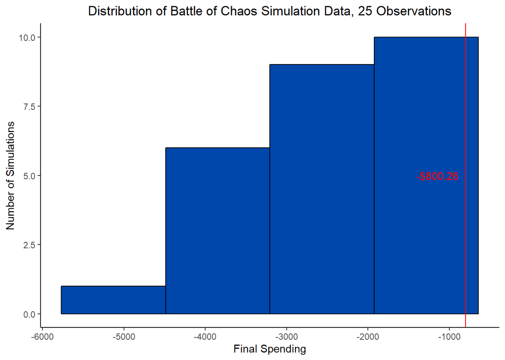

For Battle of Chaos, the average final spending was $1660.55 after any 5 Starlight Rares and the rest of the set were collected, duplicates were sold, and the unique Starlight Rares not found were bought. This means that you would have to pay $1660.55 for all unique cards in the set. The total cost to buy all individual cards was $800.26, so the buyer loses an average of $860.29 by buying boxes instead of cards. For Maximum Gold, the average final spending was $97.58 after the full card set was collected and duplicates sold. You would still have to pay $97.58 in this simulation, leaving you with less money than you started. The total cost to buy all individual cards was $193.68, so the buyer gains an average of $96.10 by buying boxes instead of individual cards. Thus, we determined that buying booster boxes for the Maximum Gold card set is more cost-effective compared to other sets and it is better to purchase the booster box rather than buying the cards individually. On the other hand, we found that buying booster boxes for the Legend of Blue Eyes White Dragon was much more costly to the buyer than purchasing the cards individually. We found that after finding all of the unique cards in that set, selling the duplicates, and compensating the original purchase of the boxes, the buyer would spend $29,369 on average. The total cost to buy all individual cards was $9,400, so the buyer loses an average of $19,969 by buying boxes instead of individual cards. Overall, we learned that this process drastically differs depending on the card set. Below we show a table summarizing each of our four simulations.

A Glimpse at Simulations for Legend of Blue Eyes

|  | Number of Boxes Opened | Final Spending |
| --- | --- | --- |
| Minimum Number of Boxes | 5 | -11699.75 |
| Maximum Number of Boxes | 45 | -58062.75 |
| Median | 14 | -27909.35 |
| Mode | 13 | … |
| Mean | 16 | -29368.9936 |

A Glimpse at Simulations for Maximum Gold

|  | Number of Boxes Opened | Final Spending |
| --- | --- | --- |
| Minimum Number of Boxes | 21 | -132.13 |
| Maximum Number of Boxes | 75 | 160.06 |
| Median | 36 | -101.8 |
| Mode | 32 | … |
| Mean | 38 | -97.57656 |

|  | Number of Boxes Opened | Final Spending |
| --- | --- | --- |
| Minimum Number of Boxes | 104 | -1873.92 |
| Maximum Number of Boxes | 529 | -4482.62 |
| Median | 219 | -2075.985 |
| Mode | Tie between 119 and 188 | … |
| Mean | 241.32 | -2423.9372 |

A Glimpse at Simulations for Battle of Chaos, getting any 5 Starlight Rares

|  | Number of Boxes Opened | Final Spending |
| --- | --- | --- |
| Minimum Number of Boxes | 12 | -221.49 |
| Maximum Number of Boxes | 390 | -4695.52 |
| Median | 114 | -1583.78 |
| Mode | Tie between 94 and 98 | … |
| Mean | 121.833 | -1660.55097 |

# CONCLUSION

We intended to discover the best variables for modeling the price of Yugioh cards and the most cost-efficient way to purchase cards. Our first question asked which card variables would be the most useful in determining the price of a card. For Monsters, Spells, Traps, and all card types, we found that *Rarity* was the best-performing predictor, but it did not outperform other variables by the amount that we had expected it to. It is important to note that the empty model performed relatively well compared to the best model, especially for Spells and Traps. Our second question explored the most cost-effective methods of purchasing complete card sets. Through our simulation, we learned that not all card sets were created equal, since some of our card simulations resulted in a profit while some produced a deficit for the buyer. Ultimately, our simulation provided useful information on how to approach the purchase of different card sets, demonstrating the ways that they differ depending on the card set.

Everything that we investigated is undeniably useful for a Yu-Gi-Oh player or a card collector. By using our data analysis, a collector could learn how certain variables impact the price of cards, specifically the large influence of *Rarity* on a card’s price. Additionally, they could use our simulation as a framework to determine how to buy other sets of cards. We demonstrated the potential benefits and drawbacks of purchasing card boxes instead of individual cards, indicating that the method of card buying should be carefully considered before an attempt to gather a full set. Though our data relates to Yu-Gi-Oh fans specifically, it is not limited to them. Through our analysis, we explored methods for anyone to collect or resell cards efficiently. The accessibility of our information is what makes our data analysis so useful, and it provides ways to make money even if you have no prior knowledge of Yu-Gi-Oh.

There are several avenues we see for potential improvement of our project. An immediate possibility is the inclusion of more variables and more complete data for modeling. As described earlier, we were only able to scrape price data from YugiohPrices for just 4,953 of the 8,361 unique cards in our data set. This was the result of an issue in how the website stored card and price data, with some card pages having more *Card Numbers* than price data. For example, the Witch of the Black Forest had 11 *Card Numbers*, but only price data for 10 cards. While we initially believed any excess *Card Numbers* would always be scraped to be at the end of our string, it appeared to be inconsistent. As a result, there was no way to match the data correctly and with enough confidence in instances where the number of card numbers and prices scraped differed. We decided to exclude instances where there was a discrepancy between the number of *Card Numbers* and the number of prices scraped and, as a result, went from around 1,000 missing values to just over 3,000. We tried to scrape more complete price data from TCGPlayer.com, but they used a dynamic JavaScript table that we were unable to scrape after multiple attempts. If more complete price data could be collected, a larger sample of the total Yugioh TCG cards would be represented in the analysis. This could also be achieved by collecting data for more cards (i.e. expanding the dataset beyond the 8,361 initially included). Further, there are several variables we couldn’t access that we believe would have been useful in predicting price. Data for card and card set release dates would have allowed us to calculate a card’s age, something we believe would be important in determining its value. We also believe the season of release could correspond to consumer purchasing behaviors, thus affecting how many cards are in circulation and an individual card’s value. Historical card price data could also be incorporated into a similar analysis that attempts to answer the question of how certain cards change in value over time. These data were not included in our original dataset but could be web-scraped from online sources. In addition to improvements to our data, some refinements could have been made to our modeling methods. While several combinations of our predictor variables were considered in modeling, many were unable to be considered due to their computational complexity. In addition, we were severely limited in our ability to consider interaction terms, due to the relatively small sample size of our data. By expanding the data as above, more advanced models could be reliably considered in analysis.

Additionally, we could have applied our simulation to a wider variety of card sets. Since our chosen card sets performed very differently, it would have been useful to see our simulation on an even greater number of card sets. We still believe sets with similar rarity ratios to those simulated could pull from our work. It is important to note that we made many assumptions in simulating the box opening experience. We assumed all cards with same rarities have an equal probability of appearing in a set; in reality some cards have lower probability due to short printing even if they have the same rarity. We did not use short prints in our rarity, because we could not find a reliable source to find out their probability of obtaining in a booster pack. We also assumed that we could successfully sell all of our duplicate cards for their market price, which may not be realistic. We assumed that time is not a factor in our simulation and the market price does not change between obtaining cards and reselling duplicates. We also made multiple assumptions about the grading of cards in the Legend of Blue Eyes card set, since the grade that PSA gives will vary depending on the card. The are many different grading scales which would chance the simulation drastically. For example a perfect grade for the Blue-Eyes White Dragon would bring the value of the card around $40,000, but we did not consider this variation in our simulation. Though we listed multiple potential improvements, we were still able to answer our two questions about the prices of Yu-Gi-Oh cards and perform a robust analysis that future work could readily build upon.

# References

1 - [https://www.db.yugioh-card.com/yugiohdb/]  
2 - [https://yugioh.fandom.com/wiki/Yu-Gi-Oh!_Trading_Card_Game]  
3 - [https://yugiohprices.com/]  
4 - [https://selectorgadget.com/]  
5 - [https://www.tcgplayer.com/categories/trading-and-collectible-card-games/yugioh/price-guides]  
6 - [https://link.springer.com/article/10.1007/BF01025868]